# Kaggle Plant Disease Classification

hbmaclean

2025-08-04

# 1 Introduction

This is just another side project to keep me learning. I picked this one in particular to try a source other than [UCI](https://archive.ics.uci.edu/datasets) and because it had some notebooks listed that I can gauge against. I scanned about five of the notebooks - all were python-based, looked very similar, and had accuracy around 75-85%.

Below is a description of the data from [Kaggle](https://www.kaggle.com/datasets/turakut/plant-disease-classification).

> Plant diseases cause significant agricultural losses worldwide. Early prediction of disease outbreaks can help farmers take preventive measures. This synthetic dataset simulates environmental conditions that might lead to fungal infections in plants.

> The dataset contains 10,000 samples representing environmental measurements from different farm locations with the following features:
> - **temperature**: Measured in degrees Celsius
> - **humidity**: Measured as percentage
> - **rainfall**: Measured in millimeters
> - **soil_pH**: Acidity/alkalinity measurement
> - **disease_present**: Binary label (0 = healthy, 1 = diseased)

# 2 Importing Packages

```r
repo <- "http://cran.us.r-project.org"
packages <- c(
    'curl', 'stringr', 'dplyr', 'tidyr', 'data.table', 'caret', 'tibble',
    'kableExtra', 'ggcorrplot', 'gridExtra', 'GGally', 'stats', 'rstatix',
    'ranger', 'tuneRanger', 'mlr', 'randomForest', 'missMethods', 'nnet',
    'naivebayes', 'matrixStats', 'earth', 'mda', 'hda', 'bnclassify', 'rocc',
    'VGAM', 'HiDimDA', 'DT', 'devtools'
)
for (package in packages) {
    if (!require(package, character.only = TRUE)) {
        install.packages(package, repos = repo)
        library(package, character.only = TRUE)
    }
}

install_github('munoztd0/reprtree')
eval(substitute(library(pkg), list(pkg='reprtree')))
library(reprtree)

set.seed(34)
```

# 3 Fetching the Data

Rather than setting up API keys and assuming the reader will do the same, I fetch instead with `curl`. Straightforward, other than that the CSV has column names in the first row.

```r
fetch_data <- function() {
    options(timeout = 120)
    url <- paste0(
        'https://www.kaggle.com/api/v1/datasets/download/',
        'turakut/plant-disease-classification'
    )
    tmp <- tempfile()
    curl_download(url, tmp)
    data <- as.data.frame(
        read.csv(
            unz(tmp, 'plant_disease_dataset.csv'),
            header = FALSE,   # first row has column names
            skip = 1          # skip them
        )
    )
    colnames(data) <- c(
        'temperature', 'humidity', 'rainfall', 'soil_ph', 'disease_present'
    )
    return(data)
}
```

## 3.1 Data Sample

```r
plant_df <- fetch_data()
head(plant_df) |> kable() |> kable_styling()
```

| temperature | humidity | rainfall | soil_ph | disease_present |
| --- | --- | --- | --- | --- |
| 27.48357 | 33.21505 | 0.5727578 | 4.975875 | 1 |
| 24.30868 | 36.94501 | 42.5223463 | 8.165266 | 0 |
| 28.23844 | 34.02619 | 16.0953032 | 6.316734 | 1 |
| 32.61515 | 41.10418 | 20.3110155 | 6.164949 | 0 |
| 23.82923 | 51.97179 | 11.8513233 | 8.482468 | 0 |
| 23.82932 | 32.28958 | 2.0585638 | 5.727685 | 0 |

# 4 Partitioning

```r
index    <- createDataPartition(y = plant_df$disease_present, times = 1, p = 0.5, list = FALSE)
train_df <- plant_df[index,]
test_df  <- plant_df[-index,]
```

## 4.1 Class Distribution

Good for the plants - only 24% are diseased.

```r
prop.table(table(plant_df$disease_present)) |>
    kable(col.names = c('disease_present', 'proportion')) |>
    kable_styling(full_width = FALSE, position = 'left')
```

| disease_present | proportion |
| --- | --- |
| 0 | 0.759 |
| 1 | 0.241 |

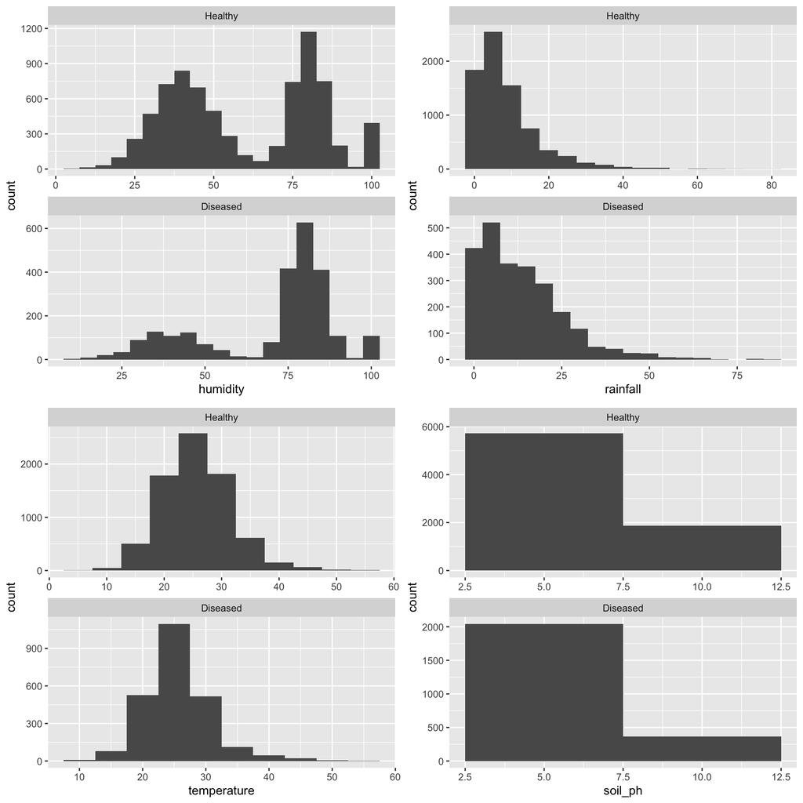

```r
common <- c(
     geom_histogram(binwidth = 5),
     facet_wrap(
         disease_present ~ .,
         nrow     = 2,
         scales   = 'free',
         labeller = as_labeller(c('0' = 'Healthy', '1' = 'Diseased'))
     )
)

p1 <- plant_df |> ggplot(aes(humidity))    + common
p2 <- plant_df |> ggplot(aes(rainfall))    + common
p3 <- plant_df |> ggplot(aes(temperature)) + common
p4 <- plant_df |> ggplot(aes(soil_ph))     + common
grid.arrange(
    p1, p2, p3, p4, ncol = 2
)
```

## 4.2 Missing Values, Outliers, Extreme Values

There are no missing values nor extreme values, but evidently some outliers to potentially impute.

```r
c(
    'missing'  = any(is.na(plant_df)),
    'outlying' = any(rstatix::is_outlier(plant_df |> as.matrix())),
    'extreme'  = any(rstatix::is_extreme(plant_df |> as.matrix()))
) |> kable(col.names = c('Values', 'Occurrence')) |>
     kable_styling(full_width = FALSE, position = 'left')
```

| Values | Occurrence |
| --- | --- |
| missing | FALSE |
| outlying | TRUE |
| extreme | FALSE |

Since there are outliers, I’ll tuck aside a copy of `train_df` with outliers set to `NA` - to be imputed later.

```r
train_o      <- train_df |> as.matrix()
outliers     <- rstatix::is_outlier(train_o)
idx          <- which(outliers[,2:ncol(train_o)])
train_o[idx] <- NA
train_o      <- train_o |> as.data.frame()
```

# 5 Row- and Column SDs

Here I use standard deviation as a proxy for volatility, and look for an observable difference between diseased and healthy cases.

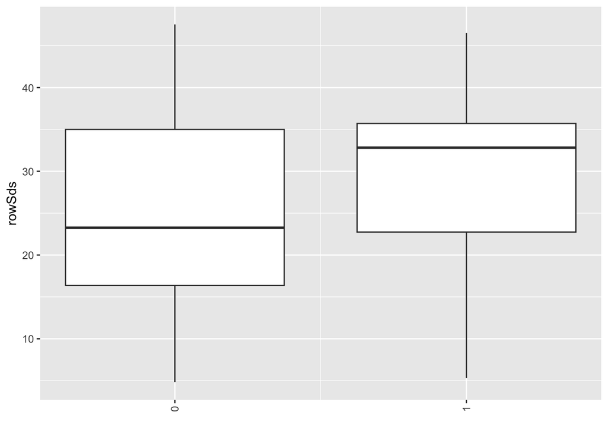

```r
x  <- plant_df$disease_present
y  <- matrixStats::rowSds(plant_df[,1:4] |> as.matrix())
ggplot() +
    geom_boxplot(aes(x, y, group = x)) +
    scale_x_continuous(
        breaks = c(0,1),
    ) +
    theme(axis.text.x = element_text(angle = 90, vjust = .5, hjust = 1)) +
    labs(x = '', y = 'rowSds')
```

Row-wise, diseased observations have a narrower IQR and considerably higher mean.

Now I take a similar look at columns’ standard deviations and means.

```r
plant_df |>
    group_by(disease_present) |>
    dplyr::summarize(across(everything(), list(mean = mean, sd = sd))) |>
    kable(
        digits = 3,
        col.names = c('diseased', rep(c('mean', 'sd'), 4))
    ) |>
    kable_styling(
        bootstrap_options = c('bordered', 'striped'),
        full_width = FALSE,
        position = 'left'
    ) |>
    add_header_above(c(' ', 'temp' = 2, 'humidity' = 2, 'rain' = 2, 'soil/ph' = 2))
```

| diseased | temp mean | temp sd | humidity mean | humidity sd | rain mean | rain sd | soil/ph mean | soil/ph sd |
| --- | --- | --- | --- | --- | --- | --- | --- | --- |
| 0 | 25.615 | 6.031 | 59.573 | 22.859 | 8.594 | 8.707 | 6.300 | 1.354 |
| 1 | 25.603 | 5.071 | 70.138 | 20.103 | 13.629 | 12.034 | 6.075 | 1.108 |

Column-wise, the two classes are fairly similar in terms of `temperature` and `soil_ph`; but diseased observations have considerably higher mean for `humidity` and `rainfall`, as well as a considerably higher deviation for `rainfall`. Perhaps these facts can be incorporated as case weights or formula interactions.

# 6 Dimension Reduction

I have low expectations here since there are only four predictors.

## 6.1 Near-Zero Variability

To the contrary, almost all data points are unique.

```r
plant_df |> select(-c(disease_present)) |>
    summarise_all(n_distinct) |>
    pivot_longer(everything(), names_to = 'Column', values_to = 'N_Distinct') |>
    mutate(Variability = N_Distinct/nrow(plant_df) * 100) |>
    arrange(desc(N_Distinct)) |>
    knitr::kable(
        digits  = 2,
        align   = 'l',
        caption = 'Plant Disease Feature Variability'
    ) |>
    kable_styling(
        bootstrap_options = c('bordered', 'striped'),
        full_width = FALSE,
        position = 'left'
    )
```

Plant Disease Feature Variability

| Column | N_Distinct | Variability |
| --- | --- | --- |
| temperature | 10000 | 100.00 |
| rainfall | 10000 | 100.00 |
| soil_ph | 10000 | 100.00 |
| humidity | 9501 | 95.01 |

## 6.2 Principal Component Analysis

Nothing worthwhile here either - all features contribute rather evenly to the overall variance.

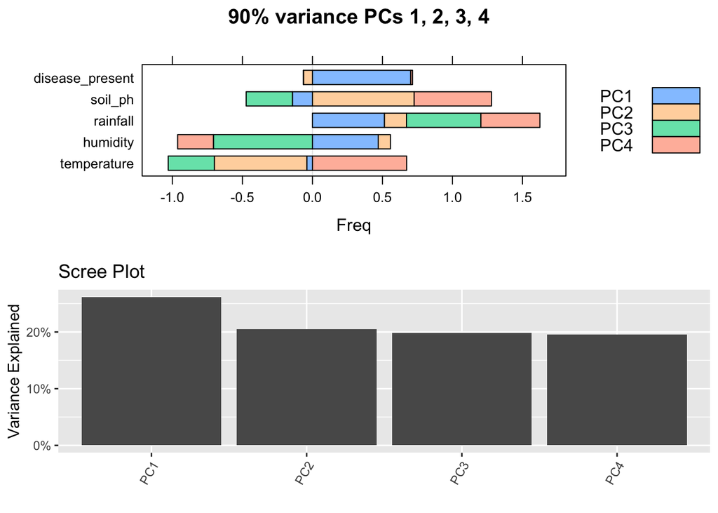

```r
pca <- prcomp(plant_df, scale = TRUE)
PCs <- which(cumsum(pca$sdev^2)/sum(pca$sdev^2) < 0.90)
s   <- summary(pca)
p1  <- barchart(
    pca$rotation[,1:length(PCs)],
    auto.key = TRUE,
    main = sprintf(
        '90%% variance PCs %s',
        paste(PCs, collapse = ', ')
    )
)
p2 <- s$importance[,1:4] |>
    as.data.frame() |>
    rownames_to_column() |>
    filter(rowname == 'Proportion of Variance') |>
    pivot_longer(-rowname) |>
    dplyr::select(-rowname) |>
    mutate(name = reorder(name, desc(value))) |>
    ggplot(aes(name, value)) +
    geom_col() +
    labs(x = '', y = 'Variance Explained', title = 'Scree Plot') +
    theme(axis.text.x = element_text(angle = 60, vjust = 1, hjust = 1)) +
    scale_y_continuous(labels = scales::percent)

grid.arrange(p1, p2, nrow = 2)
```

## 6.3 Correlation

All correlations are weak, features appear to be independent of one another.

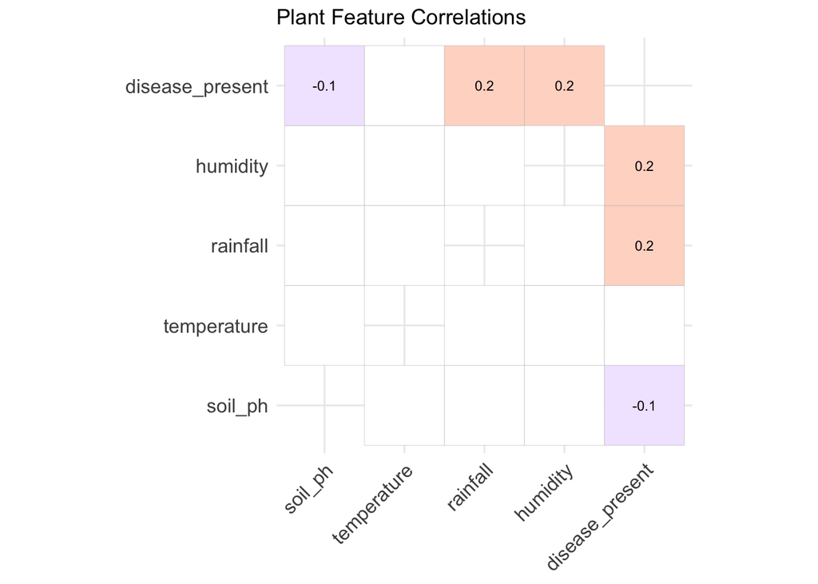

```r
# matrix of correlation p-values (conflict with rstatix w/o qualification)
p.mat <- ggcorrplot::cor_pmat(plant_df)

ggcorrplot(
    cor(plant_df),
    hc.order    = TRUE,     # reorder layout with hierarchical clustering
    hc.method   = 'median', # see ?hclust for other methods
    lab         = TRUE,     # adds correlation coefficients
    lab_size    = 3,
    digits      = 1,
    show.diag   = FALSE,    # omits self-correlation diagonal
    p.mat       = p.mat,    # p-values
    sig.level   = 0.001,    # p-value threshold
    insig       = 'blank',  # omits correlations with p-values below threshold
    show.legend = FALSE,
    title       = 'Plant Feature Correlations'
)
```

But, `humidity`, `rainfall`, and `soil_ph` correlations with the outcome have very low p-values, indicated by `***`.

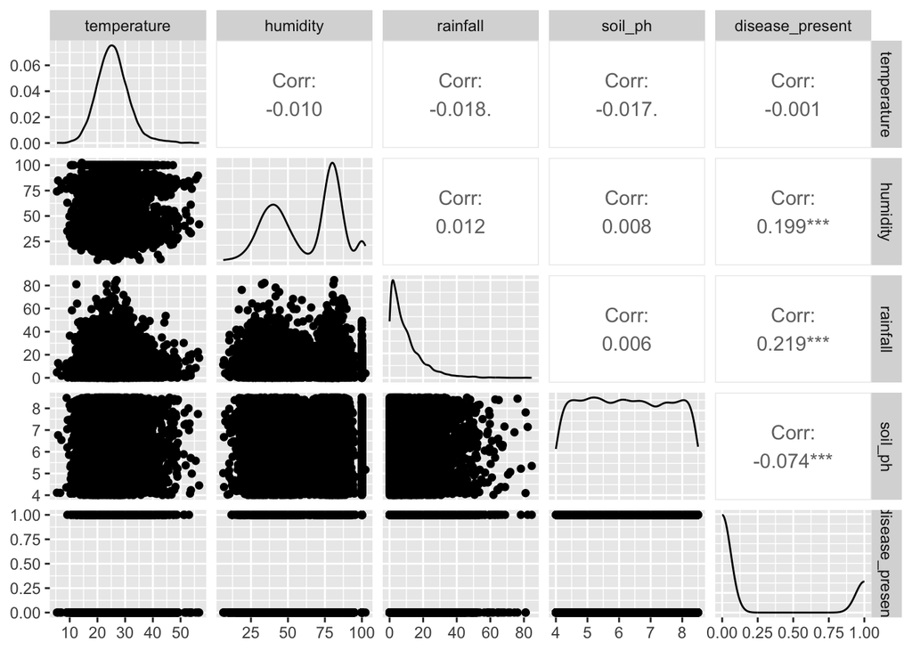

```r
ggpairs(plant_df)
```

## 6.4 Analysis of Variance (AOV)

[AOV](https://www.rdocumentation.org/packages/stats/versions/3.6.2/topics/aov) does caution that it works best with balanced designs - and I assume this is NOT, given the class distribution of about 75%/25%. Otherwise, I would conclude that `rainfall` and `humidity` are most influential.

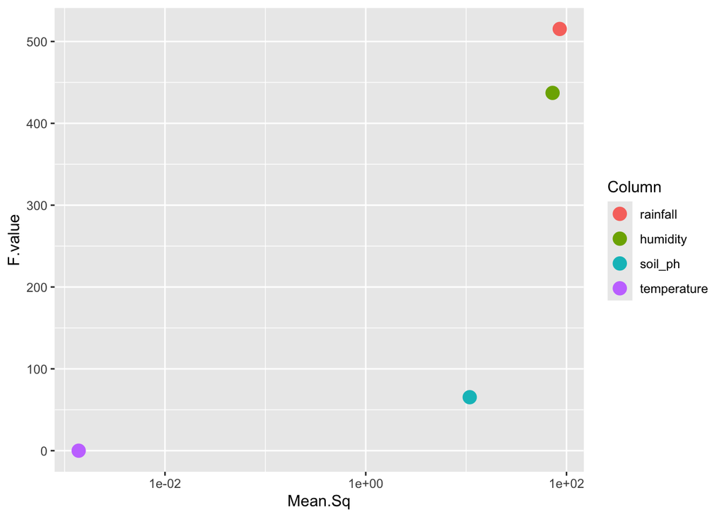

```r
unclass(summary(stats::aov(disease_present ~ ., data = plant_df))) |>
    as.data.frame() |>
    rownames_to_column(var = 'Column') |>
    filter(!is.na(F.value)) |>
    mutate(Column = reorder(Column, desc(F.value))) |>
    ggplot(aes(Mean.Sq, F.value, color = Column)) +
    geom_point(cex = 4) +
    scale_x_log10()
```

Concluding this topic, there is no apparent room for reduction. `corr`, `pca`, and `nzv` will surely not be worthwhile `preProcess` options.

# 7 Initial Model Framework

Here I create functions for making predictions, calculating accuracy, running individual models, tracking results, and easily running them all together. The goal is to run numerous models and then narrow down to the most accurate one or few.

## 7.1 Predictions and Accuracy

Below are functions to make predictions and calculate accuracy, using the [ellipsis](https://cran.r-project.org/web/packages/ellipsis/ellipsis.pdf) argument to allow model nuances to be passed in.

```r
predictions <- function(model, test_df, ...) {
    pred <- predict(model, test_df, ...)
    if (is.atomic(pred)) {
        predictions <- pred
    }
    else {
        predictions <- pred$predictions
    }
    predictions
}

accuracy <- function(model, test_df, verbose = FALSE, ...) {
    acc <- NA
    tryCatch({
        pred <- predictions(model, test_df, ...)
        cm   <- confusionMatrix(pred, factor(test_df$disease_present))
        acc  <- round(100*cm$overall[['Accuracy']], 3)
    },
    error = function(e) {
        if (verbose) {
            sprintf('model %s, error %s', class(model), e)
        }
    },
    finally = {
        return(acc)
    })
}
```

## 7.2 Formula and Models

And here, a basic formula; and a function for each model.

```r
fc <- as.formula(factor(disease_present) ~ .)

ranger__c <- function(train_df, test_df, formula = fc) {
    fit <- ranger(formula, train_df)
    accuracy(fit, test_df)
}

rf__c <- function(train_df, test_df, formula = fc) {
    fit <- randomForest(formula, train_df, ntree = 20)
    accuracy(fit, test_df)
}

multinom__c <- function(train_df, test_df, formula = fc) {
    fit <- multinom(formula, train_df, trace = FALSE, decay = .00015)
    accuracy(fit, test_df)
}

naive_bayes__c <- function(train_df, test_df, formula = fc) {
    fit <- naive_bayes(formula, train_df, usekernel = TRUE)
    accuracy(fit, test_df)
}

avNNet__c <- function(train_df, test_df, formula = fc) {
    fit <- avNNet(formula, train_df, size = 5, trace = FALSE)
    accuracy(fit, test_df, type = 'class')
}

knn3__c <- function(train_df, test_df, formula = fc, ...) {
    fit <- knn3(formula, train_df, ...)
    accuracy(fit, test_df, type = 'class')
}
```

## 7.3 Model Runner

Finally, a function to actually run the models and accumulate metrics.

```r
run_models <- function(.train = train_df, .test = test_df, ...) {
    results <- vector()
    results <- append(results, c(
        ranger__c(.train, .test, ...),
        rf__c(.train, .test, ...),
        multinom__c(.train, .test, ...),
        naive_bayes__c(.train, .test, ...),
        avNNet__c(.train, .test, ...),
        knn3__c(.train, .test, k = 13)
    ))
    names(results) <- c('ranger', 'rf', 'multinom', 'naive_bayes', 'avNNet', 'knn3')
    return(results)
}
```

## 7.4 Metrics Summary

Below, a function to display the metrics. At the moment, the expectation is that the named vector from `run_models` will be bound with an initial column of meaningful labels.

```r
display_summary <- function(.data) {
    .data |>
        dplyr::rename(` ` = c(1)) |>
        datatable(
            rownames = FALSE,
            width    = '75%',
            options  = list(
                dom        = 't',
                pageLength = nrow(.data)
            )
        )
}
```

## 7.5 Initial Runs - Baseline, Imputing, Scaling, Centering

With the framework defined, I run the models in various scenarios - imputing outliers, scaling, and centering.

```r
model_summary <- bind_rows(
    run_models(),
    run_models(.train = impute_mean(train_o)),
    run_models(.train = impute_median(train_o)),
    run_models(
        .train = train_df |>
            mutate(across(-c(disease_present), ~ scale(.x, center=FALSE, scale=TRUE))),
        .test  = test_df  |>
            mutate(across(-c(disease_present), ~ scale(.x, center=FALSE, scale=TRUE)))
    ),
    run_models(
        .train = train_df |>
            mutate(across(-c(disease_present), ~ scale(.x, center=TRUE, scale=FALSE))),
        .test  = test_df  |>
            mutate(across(-c(disease_present), ~ scale(.x, center=TRUE, scale=FALSE)))
    ),
    run_models(
        .train = train_df |>
            mutate(across(-c(disease_present), ~ scale(.x, center=TRUE, scale=TRUE))),
        .test  = test_df  |>
            mutate(across(-c(disease_present), ~ scale(.x, center=TRUE, scale=TRUE)))
    )
)
model_summary <- bind_cols(
    c(
        'baseline', 'mean-impute outliers', 'median-impute outliers',
        'scaled', 'centered', 'centered & scaled'
    ),
    model_summary
)

display_summary(model_summary)
```

|  | ranger | rf | multinom | naive_bayes | avNNet | knn3 |
| --- | --- | --- | --- | --- | --- | --- |
| baseline | 86.06 | 85.04 | 75.78 | 80.06 | 75.38 | 78.8 |
| mean-impute outliers | 80.46 | 80.4 | 75.74 | 76.84 | 75.38 | 78.22 |
| median-impute outliers | 80.44 | 80.74 | 75.72 | 77.34 | 75.38 | 78.2 |
| scaled | 85.88 | 85.52 | 75.82 | 80.18 | 75.38 | 82.82 |
| centered | 85.96 | 85.3 | 75.78 | 80.12 | 75.38 | 78.6 |
| centered &amp; scaled | 85.98 | 85.28 | 75.82 | 80.14 | 75.38 | 83.94 |

# 8 Second Model Framework - train()

From above, `ranger` and `randomForest` look best - always above 80%. Here, I look more closely at those two using `train`, hoping to tune them better with `preProcess`, `tuneGrid`, and `trainControl`.

## 8.1 Models and Tuning

Many models seem to be available only via `train`; others are available directly but do not conform to the typical fit/predict/confusionMatrix pattern. Since I am building a framework to run `ranger` and `randomForest` via `train`, I also chose additional classification models that I have used before or sampled arbitrarily now from this [caret list](https://rdrr.io/cran/caret/man/models.html).

First, I define a list of `tuneGrid` objects for the models, each `NULL` by default; with the names serving as a proxy for the list of models.

```r
tuning  <- list(
    'ranger'        = NULL,
    'rf'            = NULL,
    'Rborist'       = NULL,
    'svmRadial'     = NULL,
    'mlp'           = NULL,
    'xgbTree'       = NULL,
    'gamLoess'      = NULL,
    'rocc'          = NULL,
   #'hda'           = NULL,   <---- omitted, hopelessly verbose
    'glmnet'        = NULL,
    'treebag'       = NULL,
    'vglmContRatio' = NULL,
    'RFlda'         = NULL,
    'lssvmRadial'   = NULL
)
```

This is admittedly a shotgun approach, but it exposes me to more models. I actually chose more models, but skipped any that failed for any reason. Some require packages that are not in the usual location; and the following failed with, “all the Accuracy metric values are missing”:

- gbm, fda, awnb, bagFDAGCV, ada, rpartCost, dwdRadial, randomGLM, binda, lssvmLinear

I have encountered the error before and I suspect that either it could be resolved with appropriate tuning, or the model is simply not designed for the data. I may try to solve that some other day.

## 8.2 Running the Models via Train

Here I write a function to generically execute a model via `train` and capture its accuracy. Arguments allow for alternate data sets, formula, model list, `trControl` and lists of `tuneGrid` objects; and the [ellipsis](https://cran.r-project.org/web/packages/ellipsis/ellipsis.pdf) argument implicitly allows for `preProcess` and whatever else might be applicable.

```r
execute_models <- function(
    .train        = train_df,
    .test         = test_df,
    .formula      = fc,
    .models       = names(tuning),
    .tuning       = tuning[c(.models)],
    .trControl    = trainControl(method = 'repeatedcv', number = 2, p = .5),
    .preProcess   = c('center', 'scale'),
    bestTune      = FALSE,
    verbose       = FALSE,
    ...
) {
    results <- vector()
    results <- mapply(
        function(model, tune, ...) {
            acc <- NA
            tryCatch({
                fit <- caret::train(
                      .formula,
                      method        = model,
                      data          = .train,
                      trControl     = .trControl,
                      tuneGrid      = tune,
                      preProcess    = .preProcess,
                      trace         = FALSE,
                      verbosity     = 0,
                      verbose       = FALSE,
                      na.action     = na.pass,
                      ...
                )
                acc <- accuracy(fit, .test)
            },
            error = function(e) {
                if (verbose) {
                    print(c(Model = model, error = e))
                }
            },
            finally = {
                results <- append(results, acc)
                if (bestTune && !is.null(acc)) {
                    print(c(Model = model, bestTune = fit$bestTune))
                }
            })
        },
        .models,
        .tuning,
        ...
    )
    if (is.vector(results) & length(names(results))>1) {
        return(bind_rows(results))
    }
    else {
        return(results)
    }
}
```

## 8.3 First Runs - Baseline

And now I run what I’ll consider a baseline and look for the top few.

```r
baselines <- execute_models()
baselines |>
    pivot_longer(everything()) |>
    arrange(desc(value)) |>
    kable(col.names = c('Model', 'Accuracy')) |>
    kable_styling(full_width = FALSE, position = 'left')
```

| Model | Accuracy |
| --- | --- |
| rf | 85.92 |
| xgbTree | 85.80 |
| Rborist | 85.76 |
| ranger | 85.70 |
| treebag | 85.26 |
| mlp | 83.98 |
| svmRadial | 82.50 |
| lssvmRadial | 81.78 |
| gamLoess | 81.32 |
| vglmContRatio | 75.90 |
| RFlda | 75.80 |
| glmnet | 75.70 |
| rocc | 75.64 |

## 8.4 Tuning the Top Five Models

Next I’ll focus on the top five models, which appropriately are all forestry-related in name. First I will dig into each model’s `tundGrid`.

It proved to be a little tricky passing in the `tuneGrid` for a single model. Since I’ve implemented `.tuning` as an argument to `mapply`, a list is expected. Passing in a single `tuneGrid` gives an error, “incorrect number of dimensions”.

Below is one example; and for `xbgTree` I had to be careful to NOT create too large a grid!

```r
execute_models(
    .models = c('xgbTree'),
    .tuning = list(expand.grid(
        nrounds          = 10,
        max_depth        = c(2:5),
        eta              = c(.5,.7,.9),
        gamma            = c(3:6),
        colsample_bytree = c(.7,.8,.9),
        min_child_weight = c(5,10,15),
        subsample        = 1
    )),
    bestTune = TRUE
)
```

Below are the settings I settled on. Fiddling them further did not change accuracy much in either direction.

```r
tuning <- list(
    xgbTree    = expand.grid(
        nrounds          = 50,
        max_depth        = 3,
        eta              = .1,
        gamma            = .9,
        colsample_bytree = seq(.8,1,.1),
        min_child_weight = c(1:3),
        subsample        = c(1:2)
    ),
    ranger     = data.frame(
        mtry          = 2,
        splitrule     = 'hellinger',
        min.node.size = 50
    ),
    rf      = data.frame(mtry = 2),
    Rborist = data.frame(predFixed = 2, minNode   = 2),
    treebag = NULL
)
tuned <- execute_models()
tuned |>
    pivot_longer(everything()) |>
    arrange(desc(value)) |>
    kable(col.names = c('Model', 'Accuracy')) |>
    kable_styling(full_width = FALSE, position = 'left')
```

| Model | Accuracy |
| --- | --- |
| ranger | 86.78 |
| xgbTree | 86.56 |
| rf | 86.10 |
| Rborist | 86.08 |
| treebag | 85.06 |

## 8.5 Pre-Processing the Top Five Models

With the top five models tuned, I look into other `preProcess` methods.

Note, “all the Accuracy metric values are missing” occurs again with the following methods:

- ‘conditionalX’
- ‘knnImpute’
- ‘BoxCox’, but only when adjusting the associated ‘fudge’ parameter, and then only for ‘ranger’ and ‘rf’

```r
preprocessed <- bind_rows(
    execute_models(.preProcess = c('BoxCox')),
    execute_models(.preProcess = c('YeoJohnson')),
    execute_models(.preProcess = c('expoTrans')),
    execute_models(.preProcess = c('center')),
    execute_models(.preProcess = c('scale')),
    execute_models(.preProcess = c('center', 'scale')),
    execute_models(.preProcess = c('bagImpute'), .train = train_o),
    execute_models(.preProcess = c('medianImpute'), .train = train_o)
)
```

And the results:

```r
model_summary <- bind_cols(
    c(
        'baseline', 'tuned',
        'BoxCox', 'YeoJohnson', 'expoTrans', 'center', 'scale',
        'center+scale', 'bagImpute', 'medianImpute'
    ),
    bind_rows(baselines[c(names(tuned))], tuned, preprocessed),
)

display_summary(model_summary)
```

|  | xgbTree | ranger | rf | Rborist | treebag |
| --- | --- | --- | --- | --- | --- |
| baseline | 85.8 | 85.7 | 85.92 | 85.76 | 85.26 |
| tuned | 86.56 | 86.78 | 86.1 | 86.08 | 85.06 |
| BoxCox | 86.56 | 86.88 | 86.04 | 86.02 | 84.9 |
| YeoJohnson | 86.56 | 86.76 | 85.96 | 86.04 | 85.34 |
| expoTrans | 86.58 | 86.78 | 85.98 | 85.8 | 85.3 |
| center | 87.02 | 86.9 | 86.04 | 85.98 | 85.1 |
| scale | 86.52 | 86.84 | 86.02 | 85.98 | 84.86 |
| center+scale | 86.74 | 86.94 | 85.98 | 85.94 | 84.9 |
| bagImpute | 82.34 | 81.58 | 80.02 | 80.5 | 78.94 |
| medianImpute | 82.32 | 81.36 | 80.78 | 80.52 | 80.36 |

Conclusions from this:

- as seen earlier projects, imputing outliers has a measurably *harmful* effect
- otherwise, various `preProcess` options made *minor* improvements over the ‘tuned’ models
- `treebag` is lagging - its best accuracy is less than the others’ least, other than imputing

## 8.6 trainControl Methods for the Top Five Models

Now I try various `trainControl` methods. For simplicity, I rely mostly on underlying default values; and specify only `method`, and constant `number = 2` rather than default 10 or 25, for performance reasons.

```r
# Note, there is also LOOCV (leave-one-out CV) but it is computationally *intense*
trcontrolled <- bind_rows(
    execute_models(.trControl = trainControl(number = 2, method = 'boot')),
    execute_models(.trControl = trainControl(number = 2, method = 'boot632')),
    execute_models(.trControl = trainControl(number = 2, method = 'boot_all')),
    execute_models(.trControl = trainControl(number = 2, method = 'optimism_boot')),
    execute_models(.trControl = trainControl(method = 'adaptive_boot')),
    execute_models(.trControl = trainControl(number = 2, method = 'cv')),
    execute_models(.trControl = trainControl(number = 2, method = 'repeatedcv')),
    execute_models(.trControl = trainControl(method = 'adaptive_cv')),
    execute_models(.trControl = trainControl(number = 2, method = 'LGOCV')),
    execute_models(.trControl = trainControl(method = 'adaptive_LGOCV'))
)
trcontrolled <- bind_cols(
    c(
        'boot', 'boot632', 'boot_all', 'optimism_boot', 'adaptive_boot',
        'cv', 'repeatedcv', 'adaptive_cv', 'LGOCV', 'adaptive_LGOCV'
    ),
    trcontrolled
)

model_summary <- bind_rows(model_summary, trcontrolled)
display_summary(model_summary)
```

|  | xgbTree | ranger | rf | Rborist | treebag |
| --- | --- | --- | --- | --- | --- |
| baseline | 85.8 | 85.7 | 85.92 | 85.76 | 85.26 |
| tuned | 86.56 | 86.78 | 86.1 | 86.08 | 85.06 |
| BoxCox | 86.56 | 86.88 | 86.04 | 86.02 | 84.9 |
| YeoJohnson | 86.56 | 86.76 | 85.96 | 86.04 | 85.34 |
| expoTrans | 86.58 | 86.78 | 85.98 | 85.8 | 85.3 |
| center | 87.02 | 86.9 | 86.04 | 85.98 | 85.1 |
| scale | 86.52 | 86.84 | 86.02 | 85.98 | 84.86 |
| center+scale | 86.74 | 86.94 | 85.98 | 85.94 | 84.9 |
| bagImpute | 82.34 | 81.58 | 80.02 | 80.5 | 78.94 |
| medianImpute | 82.32 | 81.36 | 80.78 | 80.52 | 80.36 |

[output cut: 10 more lines]

## 8.7 Formula Modifications

I understand the *syntax* of what I’m doing here, but I cannot envision the underlying mechanics. I have no expectations, just another experiment.

```r
formulamods <- bind_rows(
    execute_models(
        .formula = as.formula(factor(disease_present) ~ humidity*rainfall + .)
    ),
    execute_models(
        .formula = as.formula(
            factor(disease_present) ~ humidity:rainfall + .
        )
    ),
    execute_models(
        .formula = as.formula(
            factor(disease_present) ~ (humidity+rainfall+temperature)^3 + .
        )
    ),
    execute_models(
        .formula = as.formula(
            factor(disease_present) ~ (humidity+rainfall+temperature)^3 + I(soil_ph^2)
        )
    )
)

formulamods <- bind_cols(
    c(
        'humidity*rain', 'humidity:rain', '(humidity+rain+temp)^3',
        '(humidity+rain+temp)^3 + ph^2'
    ),
    formulamods
)

model_summary <- bind_rows(model_summary, formulamods)
display_summary(model_summary)
```

|  | xgbTree | ranger | rf | Rborist | treebag |
| --- | --- | --- | --- | --- | --- |
| baseline | 85.8 | 85.7 | 85.92 | 85.76 | 85.26 |
| tuned | 86.56 | 86.78 | 86.1 | 86.08 | 85.06 |
| BoxCox | 86.56 | 86.88 | 86.04 | 86.02 | 84.9 |
| YeoJohnson | 86.56 | 86.76 | 85.96 | 86.04 | 85.34 |
| expoTrans | 86.58 | 86.78 | 85.98 | 85.8 | 85.3 |
| center | 87.02 | 86.9 | 86.04 | 85.98 | 85.1 |
| scale | 86.52 | 86.84 | 86.02 | 85.98 | 84.86 |
| center+scale | 86.74 | 86.94 | 85.98 | 85.94 | 84.9 |
| bagImpute | 82.34 | 81.58 | 80.02 | 80.5 | 78.94 |
| medianImpute | 82.32 | 81.36 | 80.78 | 80.52 | 80.36 |

[output cut: 14 more lines]

That had a negative effect, though not quite as bad as imputing.

Note, I tried similar formulas when running the models directly (without `train`) but continually failed with, “One or more independent variables not found in data.”

# 9 Final Efforts with Top Two

## 9.1 Combinations of Isolated Improvements

Looking at the running summary, some settings *appeared* to make minor improvements beyond the initial tuning, in isolation. I certainly do not assume that combining such improvements will result in a combined improvement - but I will try some combinations, for the top two models.

The following settings showed some promise for `xgbTree` and `ranger`, all somewhat above baseline accuracy. The table is not meant to convey combinations; the two columns are independent, each setting was in isolation.

| trainControl | preProcess |
| --- | --- |
| **xgbTree** |  |
| adaptive_cv | center, scale |
| optimism_boot | center |
| LGOCV |  |
| cv |  |
| adaptive_LGOCV |  |
| **ranger** |  |
| repeatedcv | center |
| LGOCV | scale |
| cv | BoxCox |

### 9.1.1 xgbTree

First, I run the `xgbTree` with many permutations of `trainControl` and `preProcess` settings shown above.

```r
.xgbTree <- bind_rows(
    execute_models(
        .models     = c('xgbTree'),
        .preProcess = c('BoxCox'),
        .trControl  = trainControl(method = 'adaptive_cv')
    ),
    execute_models(
        .models     = c('xgbTree'),
        .preProcess = c('center'),
        .trControl  = trainControl(method = 'adaptive_cv')
    ),
    execute_models(
        .models     = c('xgbTree'),
        .preProcess = c('scale'),
        .trControl  = trainControl(method = 'adaptive_cv')
    ),
    execute_models(
        .models     = c('xgbTree'),
        .preProcess = c('BoxCox', 'center', 'scale'),
        .trControl  = trainControl(method = 'adaptive_cv')
    ),
    execute_models(
        .models     = c('xgbTree'),
        .preProcess = c('BoxCox'),
        .trControl  = trainControl(method = 'optimism_boot')
    ),
    execute_models(
        .models     = c('xgbTree'),
        .preProcess = c('center'),
        .trControl  = trainControl(method = 'optimism_boot')
    ),
    execute_models(
        .models     = c('xgbTree'),
        .preProcess = c('scale'),
        .trControl  = trainControl(method = 'optimism_boot')
    ),
    execute_models(
        .models     = c('xgbTree'),
        .preProcess = c('BoxCox', 'center', 'scale'),
        .trControl  = trainControl(method = 'optimism_boot')
    ),
    execute_models(
        .models     = c('xgbTree'),
        .preProcess = c('BoxCox'),
        .trControl  = trainControl(method = 'LGOCV')
    ),
    execute_models(
        .models     = c('xgbTree'),
        .preProcess = c('center'),
        .trControl  = trainControl(method = 'LGOCV')
    ),
    execute_models(
        .models     = c('xgbTree'),
        .preProcess = c('scale'),
        .trControl  = trainControl(method = 'LGOCV')
    ),
    execute_models(
        .models     = c('xgbTree'),
        .preProcess = c('BoxCox', 'center', 'scale'),
        .trControl  = trainControl(method = 'LGOCV')
    ),
    execute_models(
        .models     = c('xgbTree'),
        .preProcess = c('BoxCox'),
        .trControl  = trainControl(method = 'cv')
    ),
    execute_models(
        .models     = c('xgbTree'),
        .preProcess = c('center'),
        .trControl  = trainControl(method = 'cv')
    ),
    execute_models(
        .models     = c('xgbTree'),
        .preProcess = c('scale'),
        .trControl  = trainControl(method = 'cv')
    ),
    execute_models(
        .models     = c('xgbTree'),
        .preProcess = c('BoxCox', 'center', 'scale'),
        .trControl  = trainControl(method = 'cv')
    ),
    execute_models(
        .models     = c('xgbTree'),
        .preProcess = c('BoxCox'),
        .trControl  = trainControl(method = 'adaptive_LGOCV')
    ),
    execute_models(
        .models     = c('xgbTree'),
        .preProcess = c('center'),
        .trControl  = trainControl(method = 'adaptive_LGOCV')
    ),
    execute_models(
        .models     = c('xgbTree'),
        .preProcess = c('scale'),
        .trControl  = trainControl(method = 'adaptive_LGOCV')
    ),
    execute_models(
        .models     = c('xgbTree'),
        .preProcess = c('BoxCox', 'center', 'scale'),
        .trControl  = trainControl(method = 'adaptive_LGOCV')
    )
)
```

And the results:

```r
bind_cols(
        c(
            rep('adaptive_cv', 4),
            rep('optimism_boot', 4),
            rep('LGOCV', 4),
            rep('cv', 4),
            rep('adaptive_LGOCV', 4)
        ),
        c(
            rep(c('BoxCox', 'center', 'scale', 'BoxCox,center,scale'), 5)
        ),
       .xgbTree
) |>
    dplyr::rename(
        trControl = c(1),
        preProcess = c(2),
        Accuracy = c(3)
    ) |>
    datatable(
        rownames = FALSE,
        width    = '50%',
        caption  = 'xgbTree',
        options  = list(dom = 't', pageLength = nrow(.xgbTree))
    )
```

| trControl | preProcess | Accuracy |
| --- | --- | --- |
| adaptive_cv | BoxCox | 86.66 |
| adaptive_cv | center | 86.56 |
| adaptive_cv | scale | 86.74 |
| adaptive_cv | BoxCox,center,scale | 86.82 |
| optimism_boot | BoxCox | 86.92 |
| optimism_boot | center | 87.04 |
| optimism_boot | scale | 86.94 |
| optimism_boot | BoxCox,center,scale | 86.9 |
| LGOCV | BoxCox | 86.58 |
| LGOCV | center | 86.58 |

[output cut: 10 more lines]

### 9.1.2 ranger

Now the same for `ranger`.

```r
.ranger <- bind_rows(
    execute_models(
        .models = c('ranger'),
        .preProcess = c('BoxCox'),
        .trControl = trainControl(method = 'repeatedcv')
    ),
    execute_models(
        .models = c('ranger'),
        .preProcess = c('center'),
        .trControl = trainControl(method = 'repeatedcv')
    ),
    execute_models(
        .models = c('ranger'),
        .preProcess = c('scale'),
        .trControl = trainControl(method = 'repeatedcv')
    ),
    execute_models(
        .models = c('ranger'),
        .preProcess = c('BoxCox', 'center', 'scale'),
        .trControl = trainControl(method = 'repeatedcv')
    ),
    execute_models(
        .models = c('ranger'),
        .preProcess = c('BoxCox'),
        .trControl = trainControl(method = 'LGOCV')
    ),
    execute_models(
        .models = c('ranger'),
        .preProcess = c('center'),
        .trControl = trainControl(method = 'LGOCV')
    ),
    execute_models(
        .models = c('ranger'),
        .preProcess = c('scale'),
        .trControl = trainControl(method = 'LGOCV')
    ),
    execute_models(
        .models = c('ranger'),
        .preProcess = c('BoxCox', 'center', 'scale'),
        .trControl = trainControl(method = 'LGOCV')
    ),
    execute_models(
        .models = c('ranger'),
        .preProcess = c('BoxCox'),
        .trControl = trainControl(method = 'cv')
    ),
    execute_models(
        .models = c('ranger'),
        .preProcess = c('center'),
        .trControl = trainControl(method = 'cv')
    ),
    execute_models(
        .models = c('ranger'),
        .preProcess = c('scale'),
        .trControl = trainControl(method = 'cv')
    ),
    execute_models(
        .models = c('ranger'),
        .preProcess = c('BoxCox', 'center', 'scale'),
        .trControl = trainControl(method = 'cv')
    )
)
```

And the results:

```r
bind_cols(
        c(
            rep('repeatedcv', 4),
            rep('LGOCV', 4),
            rep('cv', 4)
        ),
        c(
            rep(c('BoxCox', 'center', 'scale', 'BoxCox,center,scale'), 3)
        ),
       .ranger
) |>
    dplyr::rename(
        trControl = c(1),
        preProcess = c(2),
        Accuracy = c(3)
    ) |>
    datatable(
        rownames = FALSE,
        width    = '50%',
        caption  = 'ranger',
        options  = list(dom = 't', pageLength = nrow(.ranger))
    )
```

| trControl | preProcess | Accuracy |
| --- | --- | --- |
| repeatedcv | BoxCox | 86.78 |
| repeatedcv | center | 86.86 |
| repeatedcv | scale | 86.76 |
| repeatedcv | BoxCox,center,scale | 86.76 |
| LGOCV | BoxCox | 86.76 |
| LGOCV | center | 86.82 |
| LGOCV | scale | 86.84 |
| LGOCV | BoxCox,center,scale | 86.8 |
| cv | BoxCox | 86.84 |
| cv | center | 86.82 |

[output cut: 2 more lines]

I will stop there, having turned every dial I can conceive.

# 10 Loose Ends

## 10.1 Ranger Case- and Class Weights

`ranger` supports case- and class weights. I have used them before and know they can be very effective at balancing lopsided data. So far I’ve found the balancing to be a zero-sum effort in terms of accuracy/RMSE; for example, accuracy for true negatives may improve at the expense of true positives.

I create case weights (weighing each observation) with `parsnip::importance_weights` and, just a guess, `rowSds`.

To weigh the two classes, I refer again to [this article](https://medium.com/@ravi.abhinav4/improving-class-imbalance-with-class-weights-in-machine-learning-af072fdd4aa4).

```r
.case_weights = parsnip::importance_weights(
    rowSds(train_df[1:4] |> as.matrix()) |>
    as.vector()
)
.class_weights <- c(
    nrow(train_df) / (2 * sum(train_df$disease_present == 0)),
    nrow(train_df) / (2 * sum(train_df$disease_present == 1))
)
```

I know from the past that weights may work seamlessly via `train` for *bootstrap methods*; but fail for cross-validation methods. This makes sense, as each cross-validation fold will be shorter in length than the full list of weights. I use a known workaround for cv, after trying `train` and bootstrap.

### 10.1.1 Weights with Bootstrap via Train

```r
.boot <- bind_rows(
      execute_models(
          .models        = c('ranger'),
          .trControl     = trainControl(method = 'boot'),
          .preProcess    = c('center')
      ),
      execute_models(
          .models        = c('ranger'),
          .trControl     = trainControl(method = 'boot'),
          .preProcess    = c('center'),
          case.weights   = list(.case_weights)
      ),
      execute_models(
          .models        = c('ranger'),
          .trControl     = trainControl(method = 'boot'),
          .preProcess    = c('center'),
          class.weights  = list(.class_weights)
      ),
      execute_models(
          .models        = c('ranger'),
          .trControl     = trainControl(method = 'boot'),
          .preProcess    = c('center'),
          case.weights   = list(.case_weights),
          class.weights  = list(.class_weights)
      )
)
```

### 10.1.2 Weights with Cross-Validation

Here I simulate cross-validation per [this solution](https://github.com/imbs-hl/ranger/issues/419), iterating over 10 folds. It begs the question though, given one accuracy result per fold, what is the final accuracy? Perhaps average?

```r
n            <- nrow(train_df)
num_folds    <- 10
folds        <- split(sample(n), cut(1:n, num_folds, labels = FALSE))

.cv <- sapply(folds, function(fold) {
    .test  <- train_df[fold,]
    .train <- train_df[-fold,]
    fit    <- ranger(factor(disease_present) ~ ., .train)
    fit_a  <- ranger(factor(disease_present) ~ ., .train, case.weights = .case_weights[-fold])
    fit_b  <- ranger(factor(disease_present) ~ ., .train, class.weights = .class_weights)
    fit_ab <- ranger(factor(disease_present) ~ ., .train, case.weights = .case_weights[-fold], class.weights = .class_weights)
    c(
        baseline     = accuracy(fit, .test),
        caseWeights  = accuracy(fit_a, .test),
        classWeights = accuracy(fit_b, .test),
        bothWeights  = accuracy(fit_ab, .test)
    )
})
```

And the results:

```r
bind_cols(
    c('baseline', 'caseWeights', 'classWeights', 'bothWeights'),
    .cv,
    .boot
) |> kable(col.names = c('', paste(rep('fold',10), 1:10), '')) |>
     add_header_above(c('', 'cross-validation' = 10, 'boot' = 1)) |>
     kable_styling(
         bootstrap_options = c('bordered', 'striped'),
         full_width = FALSE,
         position = 'left'
    )
```

|  | cross-validation fold 1 | cross-validation fold 2 | cross-validation fold 3 | cross-validation fold 4 | cross-validation fold 5 | cross-validation fold 6 | cross-validation fold 7 | cross-validation fold 8 | cross-validation fold 9 | cross-validation fold 10 | boot |
| --- | --- | --- | --- | --- | --- | --- | --- | --- | --- | --- | --- |
| baseline | 86.2 | 87.0 | 85.6 | 85.8 | 85.6 | 85.8 | 86.8 | 83.8 | 84.8 | 85.6 | 86.90 |
| caseWeights | 85.8 | 87.2 | 85.8 | 86.6 | 85.4 | 85.6 | 87.0 | 83.8 | 84.4 | 86.0 | 86.76 |
| classWeights | 85.8 | 87.4 | 84.8 | 85.8 | 85.2 | 85.2 | 86.6 | 84.0 | 84.4 | 85.6 | 84.50 |
| bothWeights | 86.2 | 86.8 | 85.8 | 86.0 | 85.4 | 85.6 | 86.8 | 84.2 | 84.4 | 86.4 | 85.46 |

I conclude that neither class- nor case weights help accuracy here. (Granted, my calculation for case weights was guesswork.)

I leave open the question whether weights helped balance specificity and sensitivity.

### 10.1.3 Weights with dplyr

[This article](https://www.tidyverse.org/blog/2022/05/case-weights/) suggests another approach, which I will try here.

```r
execute_models(
    .models        = c('ranger'),
    .trControl     = trainControl(method = 'cv'),
    .preProcess    = c('center'),
    .train         = train_df |> dplyr::mutate(
        case_wts = parsnip::importance_weights(.class_weights[disease_present+1])
    ),
    .test          = test_df  |> dplyr::mutate(
        case_wts = parsnip::importance_weights(.class_weights[disease_present+1])
    )
)
```

```
## ranger
##    100
```

Hold on, this *must* be cheating - it creates another binary column having 100% correlation with the outcome…

This seems equivalent to setting `case_wts = disease_present`, or adding the outcome to the right hand side of the formula, e.g. `factor(disease_present) ~ . + disease_present` (both of which also give 100% accuracy.)

## 10.2 Custom-Tuning Ranger

While poking around, I found [tuneRanger](https://cran.r-project.org/web/packages/tuneRanger/tuneRanger.pdf). Its `tuneMtryFast` indicates that the out-of-bag (OOB) error varies very little for any `mtry` near 1. (I did not know that `mtry` could be zero or fractional.)

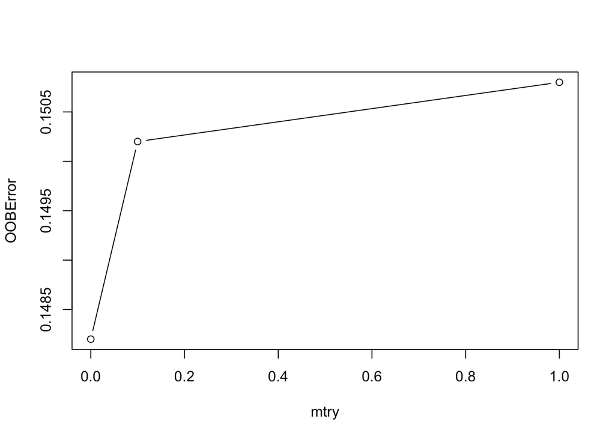

```r
sink(nullfile())
res <- tuneMtryFast(
    fc,
    data       = train_df,
    mtryStart  = .1,
    stepFactor = .1,
    improve    = .05,
    trace      = FALSE,
    plot       = FALSE
)
sink()
plot(res, type = 'b')
```

### 10.2.1 Comparing tuneRanger/ranger and Positive Class

The package also provides some other tools worth trying. Here I try `tuneRanger`, which first needs a “task” object from `mlr`. Then, evidently, `estimateTimeTuneRanger` will estimate how long to expect to process the “task” with `tuneRanger`; and a prediction can be made with the result of `tuneRanger`.

Out of curiosity I also fit `ranger` directly with the recommended tuning from `tuneRanger` to compare their accuracy.

While preparing this, I notice `makeCLassifTask` has a `positive` parameter to indicate the positive class, so I put this in a repeatable function and collect the metrics for both classes.

```r
compare_tuneRanger_and_ranger <- function(positive_class) {
    # 1. Create classification task
    task <- mlr::makeClassifTask(
        data     = train_df,
        target   = 'disease_present',
        positive = positive_class
    )

    # 2. Get its estimated execution time (suppressing other output)
    sink(nullfile())
    etime <- estimateTimeTuneRanger(task)
    sink()

    # 3. Execute task, capturing time
    rtime <- system.time(
        res <- tuneRanger(
            task,
            measure        = list(acc), # or multiclass.brier,, auc, logloss, ...
            num.trees      = 1000,
            num.threads    = 2,
            iters          = 20,
            save.file.path = NULL,
            show.info      = FALSE
        )
    )

    # 4. Predict with tuneRanger model
    pred      <- predict(res$model, newdata = test_df)

    # 5. Calculate its accuracy
    tuned_acc <- pred$data |>
        as.data.frame() |>
        dplyr::summarize(acc = 100*sum(truth == response)/n()) |>
        pull(acc)

    # 6. Fit ranger with the recommended parameter settings
    fit <- ranger(
        fc,
        train_df,
        mtry            = res$recommended.pars$mtry,
        min.node.size   = res$recommended.pars$min.node.size,
        sample.fraction = res$recommended.pars$sample.fraction
    )

    # 7. Report it
    tribble(
        ~PositiveClass, ~Estimated, ~Actual,
        ~Estimated, ~tuneRanger, ~ranger,
        ~mtry, ~min.node.size, ~sample.fraction,
        positive_class, etime, rtime['elapsed'],
        100*res$recommended.pars$acc,
        tuned_acc,
        accuracy(fit, test_df),
        res$recommended.pars$mtry,
        res$recommended.pars$min.node.size,
        round(res$recommended.pars$sample.fraction, 4)
    )
}

# 8. Blend the results
class1 <- compare_tuneRanger_and_ranger(positive_class = 1)
class0 <- compare_tuneRanger_and_ranger(positive_class = 0)
rbind(class1, class0) |>
    kable(digits = 3) |>
    add_header_above(
        c(' ' = 1, 'Time' = 2, 'Accuracy' = 3, 'Recommendations' = 3),
        underline = TRUE
    ) |>
    kable_paper()
```

| PositiveClass | Time Estimated | Time Actual | Accuracy Estimated | Accuracy tuneRanger | Accuracy ranger | Recommendations mtry | Recommendations min.node.size | Recommendations sample.fraction |
| --- | --- | --- | --- | --- | --- | --- | --- | --- |
| 1 | 501.3 | 111.877 | 86.260 | 86.64 | 86.56 | 3 | 12 | 0.383 |
| 0 | 485.1 | 105.110 | 86.315 | 86.46 | 86.50 | 4 | 6 | 0.232 |

The differences are negligible and vary between runs. I conclude there is no effective difference.

## 10.3 Positive Class, Factor Order

Here I make one more comparison - fitting and predicting with `ranger` against `train_df` and `test_df` as-is, with implicit factor ordering of 0, 1; and then again with explicit factor-ordering of 1,0.

```r
which_class <- function(.train = train_df, .test = test_df) {
    fit  <- ranger(fc, .train)
    pred <- predict(fit, .test)
    cm   <- confusionMatrix(pred$predictions, factor(.test$disease_present))
    c(
        accuracy = 100*cm$overall[['Accuracy']],
        correct  = diag(cm$table) |> sort()
    )
}

zero_first <- which_class()
one_first  <- which_class(
    train_df |> mutate(disease_present = factor(disease_present, ordered=T, levels=c(1,0))),
    test_df  |> mutate(disease_present = factor(disease_present, ordered=T, levels=c(1,0)))
)

cbind(zero_first, one_first) |>
    kable(caption = 'Factor Order Effect?') |>
    kable_styling(full_width = FALSE, position = 'left')
```

Factor Order Effect?

|  | zero_first | one_first |
| --- | --- | --- |
| accuracy | 85.94 | 86.04 |
| correct.1 | 740.00 | 743.00 |
| correct.0 | 3557.00 | 3559.00 |

Additional evidence for the same conclusion - differences are minimal and variable.

## 10.4 RandomForest Decision Tree

I like to get a glimpse into the “thinking” of these models, and for that I look to a `randomForest` decision tree. Unfortunately there is a trade-off between depth of information and clarity. To help, I shorten the column names and hackishly round digits to two decimals.

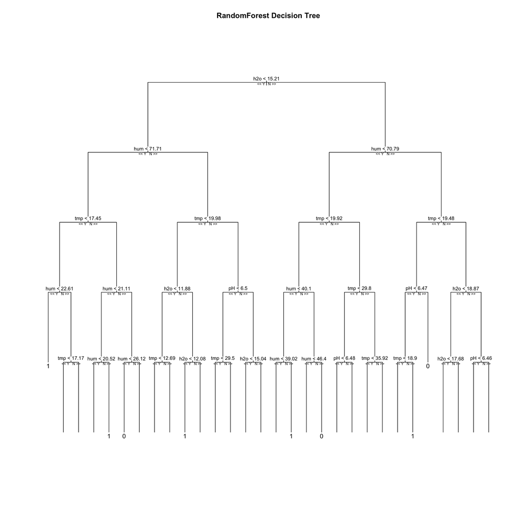

```r
fit <- randomForest(
    factor(disease_present) ~ .,
    train_df |> dplyr::rename(h2o = rainfall, tmp = temperature, pH = soil_ph, hum = humidity),
    ntree = 20
)
simplest_tree <- which.min(fit$forest$ndbigtree)
fit$forest$xbestsplit <- round(fit$forest$xbestsplit, 2)  # 'digits' workaround
plot.getTree(
    fit,
    k     = simplest_tree,
    depth = 6,
    main  = 'RandomForest Decision Tree'
)
```